# Paper-plots

Miriam Kretschmer & Vincent Fischer

28/05/2026

```r
suppressPackageStartupMessages({
library(AnnotationHub)
library(rtracklayer)
library(universalmotif)
library(MotifDb)
library(Rsamtools)
library(memes)
library(rGREAT)
library(MotifDb)
library(ggplot2)
library(ggpubr)
library(ggrepel)
library(SummarizedExperiment)
library(SEtools)
library(sechm)
library(fgsea)
library(msigdbr)
library(RColorBrewer)
library(ggvenn)
library(viridis)
library(cowplot)
library(epiwraps)
  library(chromVAR)
  library(edgeR)
  library(limma)
  library(org.Hs.eg.db)
  library(org.Mm.eg.db)
  library(clusterProfiler)
  library(GenomeInfoDb)
  library(lme4)
  library(multcomp)
  })
set.seed(123)
ah <- AnnotationHub()
source("objects/BFA_BFF.R")
source("objects/DLCAnalyzer.R")
```

```r
# function to get non redundant motifs from MotifDB
getNonRedundantMotifs <- function(){
  motifs <- MotifDb::query(MotifDb::MotifDb, c("Mmusculus","HOCOMOCO"))
  modf <- data.frame(row.names=names(motifs),
                     TF=gsub("^Mmusculus-HOCOMOCOv10-|_MOUSE.+","",names(motifs)),
                     grade=gsub(".+\\.","",names(motifs)))
  modf <- modf[order(modf$TF,modf$grade),]
  modf <- modf[!duplicated(modf$TF),]
  setNames(universalmotif::convert_motifs(motifs[row.names(modf)]), modf$TF)
}
motifs <- getNonRedundantMotifs()
motifs$GCR
```

```
##
##        Motif name:   GCR
##    Alternate name:   GCR_MOUSE.H10MO.C
##          Organism:   Mmusculus
##          Alphabet:   DNA
##              Type:   PPM
##           Strands:   +-
##          Total IC:   9.01
##       Pseudocount:   1
##         Consensus:   NRGAACANNVWGTNCHNN
##      Target sites:   4122
##        Extra info:   [dataSource] HOCOMOCOv10
##
##      N    R    G    A    A    C    A    N    N    V    W    G    T    N    C
## A 0.27 0.59 0.13 0.68 0.93 0.06 0.81 0.19 0.37 0.30 0.32 0.11 0.14 0.20 0.10
## C 0.22 0.01 0.02 0.07 0.01 0.72 0.03 0.12 0.19 0.32 0.14 0.06 0.08 0.29 0.67
## G 0.44 0.40 0.84 0.20 0.03 0.20 0.09 0.39 0.19 0.30 0.09 0.74 0.23 0.22 0.14
## T 0.07 0.01 0.01 0.05 0.03 0.02 0.07 0.30 0.25 0.09 0.46 0.08 0.54 0.29 0.10
##      H    N    N
## A 0.26 0.33 0.27
## C 0.34 0.10 0.14
## G 0.12 0.33 0.41
## T 0.28 0.23 0.18
```

```r
library(UpSetR)

regionUpset2 <- function (x = NULL, genelist = NULL, returnList = FALSE, ...)
{
    if (!is.null(genelist)) {
        x <- genelist
    }
    if (is.character(x))
        x <- as.list(x)
    stopifnot(length(x) > 1)
    if (is.list(x)) {
        if (is.null(names(x)) && all(unlist(lapply(x, is.character))) &&
            all(lengths(x) == 1))
            names(x) <- unlist(x)
        if (any(unlist(lapply(x, FUN = function(x) {
            if (is.character(x)) {
                if (length(x) != 0) return(TRUE)
                if (!file.exists(x)) return(TRUE)
            }
            FALSE
        })))) {
            stop("`x` should be a named list of character vectors.")
        }
    }
    x <- lapply(x, function(x) as.character(x))
    if (returnList)
        return(x)
    UpSetR::upset(UpSetR::fromList(x), ...)
}
```

# 1 Fig 1A - Motif enrichment sperm and oocyte

Sperm peaks

```r
d.sperm <- readRDS("objects/motif_enrichment_sperm_consensus_narrow.rds")
d.sperm <- readRDS("objects/motif_enrichment_sperm_consensus_broad.rds")

head(d.sperm)
```

| rank | motif_db | motif_id | motif_alt_id | consensus | pvalue | adj.pvalue | evalue | tests | fasta_max | pos | neg | pwm_min | tp | tp_percent | fp | fp_percent |
| --- | --- | --- | --- | --- | --- | --- | --- | --- | --- | --- | --- | --- | --- | --- | --- | --- |
| 1 | /tmp/RtmpmeQeV4/SP1 | SP1 | SP1_MOUSE.H10MO.A | GGGRRGGGGGCGGGGCSDG | 1.52e-305 | 4.00e-305 | 1.58e-305 | 26403 | 33830 | 33830 | 33830 | 12.00 | 8570 | 25.33 | 1893 | 5.60 |
| 2 | /tmp/RtmpmeQeV4/GCR | GCR | GCR_MOUSE.H10MO.C | VRGAACAKNVWGTNCHDR | 9.10e-305 | 3.53e-305 | 1.39e-305 | 38745 | 33830 | 33830 | 33830 | 2.10 | 15195 | 44.92 | 6604 | 19.52 |
| 3 | /tmp/RtmpmeQeV4/SP3 | SP3 | SP3_MOUSE.H10MO.B | SGVVGGGGGCGGGGCBRGSS | 7.75e-305 | 2.18e-305 | 8.61e-305 | 28115 | 33830 | 33830 | 33830 | 17.40 | 7496 | 22.16 | 1520 | 4.49 |
| 4 | /tmp/RtmpmeQeV4/STAT1 | STAT1 | STAT1_MOUSE.H10MO.A | BTTTCASTTYCYYTTTCYY | 1.25e-305 | 3.56e-305 | 1.41e-305 | 28395 | 33830 | 33830 | 33830 | 1.28 | 17367 | 51.34 | 8696 | 25.70 |
| 5 | /tmp/RtmpmeQeV4/ANDR | ANDR | ANDR_MOUSE.H10MO.B | RGDACABNDTGTDCTW | 4.75e-305 | 9.83e-305 | 3.88e-305 | 20703 | 33830 | 33830 | 33830 | 2.66 | 8589 | 25.39 | 2360 | 6.98 |
| 6 | /tmp/RtmpmeQeV4/IRF4 | IRF4 | IRF4_MOUSE.H10MO.C | RAAARAGRAAVTGAAA | 7.98e-305 | 1.81e-305 | 7.16e-305 | 22734 | 33830 | 33830 | 33830 | 1.79 | 12957 | 38.30 | 5633 | 16.65 |

```r
length(d.sperm$motif_id)#281
```

```
## [1] 281
```

MII oocyte peaks

```r
d.oo <- readRDS("objects/motif_enrichment_oocyte_broad.rds")

# head(d.oo)
# length(d.oo$motif_id)
# d.oo$motif_id
```

Comparing the enrichments directly, e.g. by merging two data.frames and plotting the log(p) in one vs the other highlighting top 5 for each

```r
m <- merge(d.oo, d.sperm, by="motif_id", suffixes=c(".oocyte",".sperm"))

m.oo.sort <- m[order(m[,2],decreasing = FALSE),]
m.oo5 <- m.oo.sort[1:5,]
m.sperm.sort <- m[order(m[,18],decreasing = FALSE),]
m.sperm5 <- m.sperm.sort[1:5,]
# m
```

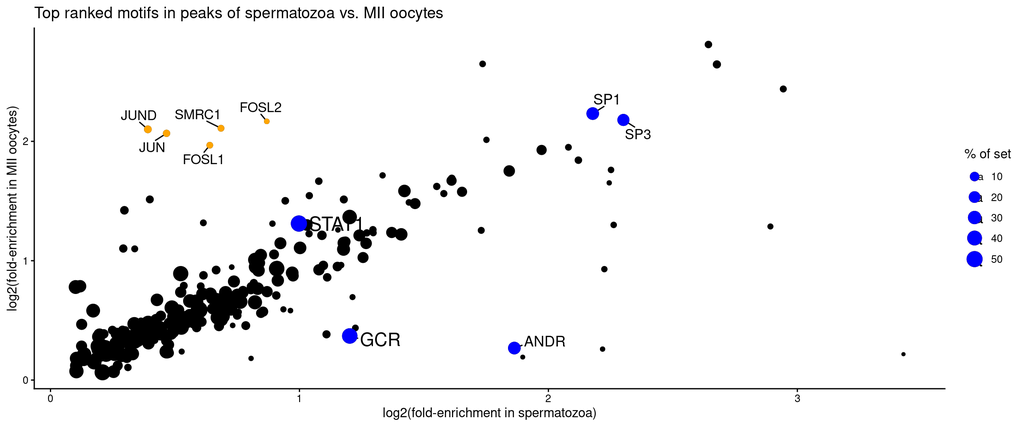

```r
ggplot(m, aes(x=log2((1+tp.sperm)/(1+fp.sperm)), y= log2((1+tp.oocyte)/(1+fp.oocyte)), size=(tp_percent.sperm))) +
  geom_point() +
  geom_text_repel(box.padding=0.5, min.segment.length = 0, max.overlaps = 10, hjust = "left", aes(label=motif_id), data=m.oo5, size=4) +
  geom_text_repel(box.padding= 0.5, min.segment.length = 0, max.overlaps = 10, hjust = "right", aes(label=motif_id), data=m.sperm5)+
  geom_point(color="orange", data=m.oo5) +
  geom_point(color="blue", data=m.sperm5) +
  labs(color="Top enriched motifs")+
  labs(x="log2(fold-enrichment in spermatozoa)", y="log2(fold-enrichment in MII oocytes)", size="% of set") +
  #ylab("-log10 (adjusted p-value MII oocyte)")+
  #xlab("-log10 (adjusted p-value spermatozoa)")+
  theme_classic() +
  #theme(legend.position = "none")+
  ggtitle("Top ranked motifs in peaks of spermatozoa vs. MII oocytes")
```

```r
  ggsave("./plots/Fig1A_motif_enrichment_sperm_vs_oocyte_peaks.svg")
ggsave("./plots/Fig1A_motif_enrichment_sperm_vs_oocyte_peaks.pdf")#, width = 6, height = 4)
ggsave("./plots/Fig1A_motif_enrichment_sperm_vs_oocyte_peaks.png")
```

# 2 Fig 1B - TF motif activity sperm vs oocyte

```r
library(TFBSTools)
sc <- readRDS("./objects/sc_sperm_oo.rds")
fa <- Rsamtools::FaFile("objects/Mus_musculus.GRCm39.dna_sm.primary_assembly.fa")

sc_gc <- addGCBias(sc, genome=fa)
motifs <- do.call(what = "PFMatrixList", lapply(getNonRedundantMotifs(), class="TFBSTools-PFMatrix", FUN= convert_motifs))
#motifs <- getNonRedundantMotifs()
motif_ix <- motifmatchr::matchMotifs(motifs, sc_gc, genome=fa)
# motif_ix
dev <- computeDeviations(object=sc_gc, annotations=motif_ix)
dev$groups <- c("sperm","sperm","MIIoocyte")

fit <- lmFit(assays(dev)$z, model.matrix(~dev$groups),background_peaks = getBackgroundPeaks(sc_gc,rowData(sc_gc)$bias,niterations = 5000))

head(mores <- topTable(eBayes(fit),number=Inf),395)
```

|  | logFC | AveExpr | t | P.Value | adj.P.Val | B |
| --- | --- | --- | --- | --- | --- | --- |
| FOSL1 | -93.7942457 | -13.246918039 | -70.18470106 | 2.379076e-09 | 3.407420e-07 | 1.22784879 |
| FOSL2 | -88.8668748 | -12.570400596 | -65.75541315 | 3.406526e-09 | 3.407420e-07 | 1.22416012 |
| JUND | -90.4344147 | -13.227632383 | -64.71712062 | 3.718547e-09 | 3.407420e-07 | 1.22318495 |
| JUNB | -89.1123216 | -12.594346736 | -63.97344397 | 3.962884e-09 | 3.407420e-07 | 1.22245736 |
| SMRC1 | -92.4478273 | -12.769939284 | -62.99679174 | 4.313189e-09 | 3.407420e-07 | 1.22146274 |
| JUN | -92.9589781 | -13.023274090 | -59.44199463 | 5.938477e-09 | 3.909497e-07 | 1.21742321 |
| FOSB | -72.2952126 | -10.347355968 | -52.72391549 | 1.149108e-08 | 6.484253e-07 | 1.20746608 |
| BATF | -87.5723390 | -12.091963647 | -50.84789480 | 1.402634e-08 | 6.925506e-07 | 1.20396661 |
| GCR | 54.4963987 | 7.272692223 | 39.69479258 | 5.474500e-08 | 2.402697e-06 | 1.17210229 |
| CTCF | -62.1240422 | -7.821102594 | -37.21446657 | 7.803992e-08 | 3.082577e-06 | 1.16095939 |

[output cut: 385 more lines]

```r
sechm::sechm(dev, head(row.names(mores)), assayName = "z", top_annotation = "groups",do.scale=TRUE)
sechm::sechm(dev, head(row.names(mores),395), assayName = "z", top_annotation = "groups",do.scale = TRUE)
```

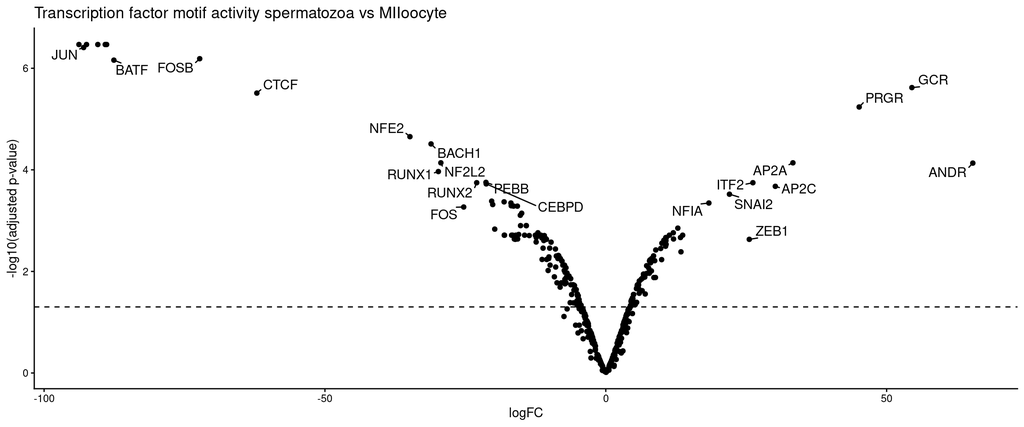

```r
ggplot(mores, aes(logFC, -log10(adj.P.Val))) +
  geom_point() +
  geom_hline(yintercept=-log10(0.05), linetype="dashed") +
  ggtitle("Transcription factor motif activity spermatozoa vs MIIoocyte") +
  theme_classic() +
  labs(y = "-log10(adjusted p-value)") +
  geom_text_repel(data = subset(mores, adj.P.Val < 0.01),
                  aes(label = rownames(subset(mores, adj.P.Val < 0.01))),
                  min.segment.length = 0,
                  size = 4)
```

```r
#geom_point(aes(color = B)) +

ggsave("./plots/Fig1B_TFmotif_activity_sperm_vs_oocyte_peaks.svg")
ggsave("./plots/Fig1B_TFmotif_activity_sperm_vs_oocyte_peaks.pdf")#, width = 6, height = 4)
ggsave("./plots/Fig1B_TFmotif_activity_sperm_vs_oocyte_peaks.png")
```

# 3 Fig 1C - Human sperm

```r
genome <- ah[["AH90808"]] #human

GRE_motif <- MotifDb::MotifDb %>%
  MotifDb::query("GRE") %>%
  universalmotif::convert_motifs() %>%
  .[[1]]
```

```r
peaks <- import("extern_data/ATAC_Corces_1_peaks.narrowPeak")
peak_seqs <- get_sequence(peaks, genome)
fimo <- runFimo(peak_seqs, GRE_motif, meme_path = "/common/meme/bin") # you need to insert your indiviudual meme path here
GRE_peaks1 <- peaks[overlapsAny(peaks, fimo)]
```

```r
length(peaks) #32027
length(fimo) #1338
sum(overlapsAny(peaks, fimo)) #716
length(GRE_peaks1) #716
```

```r
tracks <- c(
  sperm1="extern_data/ATAC_Corces_1.full.bw",
  sperm2="extern_data/ATAC_Corces_2.full.bw"
)

m <- signal2Matrix(tracks, GRE_peaks1, w = 20, BPPARAM = 4)
```

```
##   |                                                                              |                                                                      |   0%  |                                                                              |===================================                      …
```

```r
m <- epiwraps:::.ese2ml(m)

fused_sperm_mat <- mergeSignalMatrices(m[1:2])
# fused_sperm_mat

fused_m <- c(list("Human sperm"=fused_sperm_mat), m[-1:-2])


pdf("plots/Fig1C_humansperm.pdf", width=7.5, height=10)
h <- plotEnrichedHeatmaps(fused_m, row_title="Peaks from spermatozoa with GRE", raster_resize_mat = TRUE, axis_name = c("-2kb","0","+2kb"), colors = rocket(2000), mean_trim = TRUE, mean_color = "#800080", heatmap_legend_param = list(legend_direction = "horizontal", legend_width = unit(0.28, "npc"), title=NULL), use_raster = TRUE)
print(h)
dev.off()
```

```r
png("plots/Fig1C_humansperm.png")
h <- plotEnrichedHeatmaps(fused_m, row_title="Peaks from spermatozoa with GRE", raster_resize_mat = TRUE, axis_name = c("-2kb","0","+2kb"), colors = rocket(2000), mean_color = "#800080", heatmap_legend_param = list(legend_direction = "horizontal", legend_width = unit(0.28, "npc"), title=NULL), use_raster = TRUE)
print(h)
dev.off()
```

```r
svg("plots/Fig1C_humansperm.svg", width=7.5, height=10)
h <- plotEnrichedHeatmaps(fused_m, row_title="Peaks from spermatozoa with GRE", raster_resize_mat = TRUE, axis_name = c("-2kb","0","+2kb"), colors = rocket(2000), mean_color = "#800080",heatmap_legend_param = list(legend_direction = "horizontal", legend_width = unit(0.28, "npc"), title=NULL), use_raster = TRUE)
print(h)
dev.off()
```

# 4 Fig 1D - Sperm GRE peaks across spermatogenesis

```r
tracks <- c(
  uds1="extern_data/ATACse_PRJNA399533_Thy1posSpermatogonia_GSM2751121.bw",
  uds2="extern_data/ATACse_PRJNA399533_Thy1posSpermatogonia_GSM2751122.bw",
  ds1="extern_data/ATACse_PRJNA399533_cKitposSpermatogonia_GSM2751125.bw",
  ds2="extern_data/ATACse_PRJNA399533_cKitposSpermatogonia_GSM2751126.bw",
  ps1="extern_data/ATACse_PRJNA399533_PachytenSpermatocytes_GSM2751129.bw",
  ps2="extern_data/ATACse_PRJNA399533_PachytenSpermatocytes_GSM2751130.bw",
  rs1="extern_data/ATACse_PRJNA399533_RoundSpermatides_GSM2751133.bw",
  rs2="extern_data/ATACse_PRJNA399533_RoundSpermatides_GSM2751134.bw",
  sperm1="extern_data/ATAC_PRJNA480448_Sperm_GSM3262855.bw",
  sperm2="extern_data/ATAC_PRJNA480448_Sperm_GSM3262856.bw",
  sperm3="extern_data/ATAC_PRJNA315208_Sperm_GSM2088377.bw",
  sperm4="extern_data/ATAC_PRJNA315208_Sperm_GSM2088378.bw",
  GVoocyte1="extern_data/ATAC_PRJNA480448_GVOocyte_GSM3262861.bw",
  GVoocyte2="extern_data/ATAC_PRJNA480448_GVOocyte_GSM3262862.bw",
  "MII oocyte"="extern_data/ATAC_PRJNA480448_MIIOocyte_GSM3262863.bw"
)
```

```r
peaks <- readRDS("objects/narrow_peaks_with_GRE_sperm.rds")
m <- signal2Matrix(tracks, peaks, w = 20, BPPARAM = 2)
```

```
##   |                                                                              |                                                                      |   0%  |                                                                              |=====                                                    …
```

```r
m <- epiwraps:::.ese2ml(m)

fused_uds_mat <- mergeSignalMatrices(m[1:2])
fused_ds_mat <- mergeSignalMatrices(m[3:4])
fused_ps_mat <- mergeSignalMatrices(m[5:6])
fused_rs_mat <- mergeSignalMatrices(m[7:8])
fused_sperm_mat <- mergeSignalMatrices(m[9:12])
fused_gv_mat <- mergeSignalMatrices(m[13:14])

fused_m <- c(list(fused_uds=fused_uds_mat), list(fused_ds=fused_ds_mat), list(fused_ps=fused_ps_mat), list(fused_rs=fused_rs_mat), list(fused_sperm=fused_sperm_mat), list(fused_GVoocytes=fused_gv_mat), m[15], m[-1:-15])
fused_n <- renormalizeBorders(lapply(fused_m,log1p))
```

Combined in one plot

```r
pdf("plots/Fig1D_GREpeaks_from_sperm_across_spermatogenesis_normalized.pdf", width=17.5, height=10)
h <- plotEnrichedHeatmaps(fused_n, row_title="Peaks from spermatozoa with GRE", raster_resize_mat = TRUE, axis_name = c("-2kb","0","+2kb"), colors = rocket(2000), mean_color = "#800080")
print(h)
dev.off()
```

```r
png("plots/Fig1D_GREpeaks_from_sperm_across_spermatogenesis_normalized.png", height=768)
h <- plotEnrichedHeatmaps(fused_n, row_title="Peaks from spermatozoa with GRE", raster_resize_mat = TRUE, axis_name = c("-2kb","0","+2kb"), colors = rocket(2000), mean_color = "#800080")
print(h)
dev.off()
```

Single panels of heatmaps

```r
# Create a list of heatmaps
for (i in 1:length(fused_n)) {
  h <- plotEnrichedHeatmaps(fused_n[i], raster_resize_mat = TRUE, axis_name = c("-2kb","0","+2kb"), colors = rocket(2000), mean_color = "#800080",
                            heatmap_legend_param = list(legend_direction = "horizontal", legend_width = unit(0.28, "npc"), title=NULL))

  # Save each heatmap to a PDF
  pdf(paste0("plots/Fig1D_GREpeaks_from_sperm_across_spermatogenesis_normalized_", i, ".pdf"), width=2.5, height=10)
  draw(h, heatmap_legend_side="bottom", annotation_legend_side="right",  legend_grouping = "original")
  dev.off()
}
```

```r
# Create a list of heatmaps
for (i in 1:length(fused_n)) {
  h <- plotEnrichedHeatmaps(fused_n[i], raster_resize_mat = TRUE, axis_name = c("-2kb","0","+2kb"), colors = rocket(2000), mean_color = "#800080",
                            heatmap_legend_param = list(legend_direction = "horizontal", legend_width = unit(0.4, "npc"), title=NULL))

  # Save each heatmap to a PNG
  png(paste0("plots/Fig1D_GREpeaks_from_sperm_across_spermatogenesis_normalized_", i, ".png"), width=250, height=768)
  draw(h, heatmap_legend_side="bottom", annotation_legend_side="right",  legend_grouping = "original")
  dev.off()
}
```

# 5 Fig 1E - Promotors with GRE; ATAC, H3k4m3 and 5mC

```r
tracks <- c(
  sperm1="extern_data/ATAC_PRJNA480448_Sperm_GSM3262855.bw",
  sperm2="extern_data/ATAC_PRJNA480448_Sperm_GSM3262856.bw",
  sperm3="extern_data/ATAC_PRJNA315208_Sperm_GSM2088377.bw",
  sperm4="extern_data/ATAC_PRJNA315208_Sperm_GSM2088378.bw",
  sperm1_H3K4me3="extern_data/SRR3309386.bw",
  sperm2_H3K4me3="extern_data/SRR3309387.bw",
  sperm3_H3K4me3="extern_data/SRR3703039.bw",
  sperm4_H3K4me3="extern_data/SRR5049005.bw",
  sperm5_H3K4me3="extern_data/SRR3225849.bw",
  sperm1_H3K27ac="extern_data/SRR3225845.bw",
  sperm2_H3K27ac="extern_data/SRR5049001.bw",
  sperm1_H3K9ac="extern_data/SRR3225847.bw",
  sperm2_H3K9ac="extern_data/SRR5049003.bw",
  sperm1_H3K4me1="extern_data/SRR3225848.bw",
  sperm2_H3K4me1="extern_data/SRR5049004.bw",
  sperm1_H3.3="extern_data/ChIP_PRJNA480447_Sperm_GSM3262880.bw",
  sperm2_H3.3="extern_data/ChIP_PRJNA480447_Sperm_GSM3262881.bw",
  sperm1_H2A.Z="extern_data/ChIP_PRJNA480447_Sperm_GSM3262882.bw",
  sperm2_H2A.Z="extern_data/ChIP_PRJNA480447_Sperm_GSM3262880.bw"
)
```

```r
methyl_bw <- list.files(path = "intern_data/Nanopore/",pattern = "39.bw",full.names = T)
names(methyl_bw) <- c("GR_Ctrl1","GR_Ctrl2","GR_KO1","GR_KO2")

methyl_bw_ctrl <- methyl_bw[1:2]
```

```r
methyl_bed <- sapply(names(methyl_bw),function(names){
  import.bw(methyl_bw[names])

  })
```

promoters regions with GRE

```r
proms <- readRDS("objects/GRE_promoters_center.rds")
```

```r
sm2 <- signal2Matrix(w = 20L, filepaths = tracks[c(1:4,5:9)],regions = proms)
#plotEnrichedHeatmaps(sm2)
```

```r
sm_5mC <- signal2Matrix(w = 20L , smooth = T, limit = c(0,100), filepaths = methyl_bed, regions = proms)
sm2 <- sm2[rownames(sm2) %in% rownames(sm_5mC),]
```

```r
sm_merge <- mergeSignalMatrices(epiwraps:::.ese2ml(sm2)[1:4])
sm_merge_H3K4me3 <- mergeSignalMatrices(epiwraps:::.ese2ml(sm2)[5:9])
sm_merge_5mC <- mergeSignalMatrices(epiwraps:::.ese2ml(sm_5mC)[1:2])
```

```r
p <- plotEnrichedHeatmaps(ml = list(ATAC = sm_merge,H3K4me3 = sm_merge_H3K4me3),multiScale = F,row_title = "Promoters with GRE",color = rocket(2000),scale_title = "density",axis_name = c("-2kb","TSS","+2kb"), use_raster = T,mean_scale_side = "none",  heatmap_legend_param = list(legend_direction = "horizontal", legend_width = unit(0.4,"npc"), title=NULL))+
                       plotEnrichedHeatmaps(ml = list("5mC" = sm_merge_5mC),row_title = "Promoters with GRE",use_raster =TRUE, scale_title = "5mc[%]",axis_name = c("-2kb","TSS","+2kb"),mean_scale_side = "none",  heatmap_legend_param = list(legend_direction = "horizontal", legend_width = unit(0.4,"npc"), title=NULL))


  png(paste0("plots/Fig1E.png"), width=750, height=768)
  draw(p, heatmap_legend_side="bottom", annotation_legend_side="right",  legend_grouping = "original")
  dev.off()
```

```r
  pdf(paste0("plots/Fig1E.pdf"), width=7.5, height=10)
  draw(p, heatmap_legend_side="bottom", annotation_legend_side="right",  legend_grouping = "original")
  dev.off()
```

```r
  svg(paste0("plots/Fig1E.svg"), width=7.5, height=10)
  draw(p, heatmap_legend_side="bottom", annotation_legend_side="right",  legend_grouping = "original")
  dev.off()
```

each heatmap on its own

```r
#ATAC
p <- plotEnrichedHeatmaps(ml = list(ATAC = sm_merge),multiScale = F,row_title = "Promoters with GRE",color = rocket(2000),scale_title = "density",axis_name = c("-2kb","TSS","+2kb"), use_raster = T,  heatmap_legend_param = list(legend_direction = "horizontal", legend_width = unit(0.4,"npc"), title=NULL))
png(paste0("plots//Fig1EATAC.png"), width=250, height=768)
  draw(p, heatmap_legend_side="bottom", annotation_legend_side="right",  legend_grouping = "original")
  dev.off()
```

```r
  pdf(paste0("plots//Fig1EATAC.pdf"), width=2.5, height=10)
  draw(p, heatmap_legend_side="bottom", annotation_legend_side="right",  legend_grouping = "original")
  dev.off()
```

```r
  svg(paste0("plots//Fig1EATAC.svg"), width=2.5, height=10)
  draw(p, heatmap_legend_side="bottom", annotation_legend_side="right",  legend_grouping = "original")
  dev.off()
```

```r
# H3K4m3
  p <- plotEnrichedHeatmaps(ml = list(H3K4me3 = sm_merge_H3K4me3),multiScale = F,row_title = "Promoters with GRE",color = rocket(2000),scale_title = "density",axis_name = c("-2kb","TSS","+2kb"), use_raster = T,  heatmap_legend_param = list(legend_direction = "horizontal", legend_width = unit(0.4,"npc"), title=NULL))
png(paste0("plots//Fig1EH3K4me3.png"), width=250, height=768)
  draw(p, heatmap_legend_side="bottom", annotation_legend_side="right",  legend_grouping = "original")
  dev.off()
```

```r
  pdf(paste0("plots//Fig1EH3K4me3.pdf"), width=2.5, height=10)
  draw(p, heatmap_legend_side="bottom", annotation_legend_side="right",  legend_grouping = "original")
  dev.off()
```

```r
  svg(paste0("plots/Fig1EH3K4me3.svg"), width=2.5, height=10)
  draw(p, heatmap_legend_side="bottom", annotation_legend_side="right",  legend_grouping = "original")
  dev.off()
```

```r
# 5mC

p <-   plotEnrichedHeatmaps(ml = list("5mC" = sm_merge_5mC),row_title = "Promoters with GRE",use_raster =TRUE, scale_title = "5mc[%]",axis_name = c("-2kb","TSS","+2kb"),  heatmap_legend_param = list(legend_direction = "horizontal", legend_width = unit(0.4,"npc"), title=NULL))
png(paste0("plots/Fig1EH3K4me3.png"), width=250, height=768)
  draw(p, heatmap_legend_side="bottom", annotation_legend_side="right",  legend_grouping = "original")
  dev.off()
```

```r
  pdf(paste0("plots/Fig1EH3K4me3.pdf"), width=2.5, height=10)
  draw(p, heatmap_legend_side="bottom", annotation_legend_side="right",  legend_grouping = "original")
  dev.off()
```

```r
  svg(paste0("plots/Fig1EH3K4me3.svg"), width=2.5, height=10)
  draw(p, heatmap_legend_side="bottom", annotation_legend_side="right",  legend_grouping = "original")
  dev.off()
```

# 6 Fig 1F GR-ChIP

```r
bw <- list.files(path = "intern_data/ChIP/",pattern = "*.bw$",full.names = T)
names(bw) <- basename(bw)

bw <- bw[!grepl(pattern = "Input|Stress",bw)]




GR_bed <- sapply(names(bw),function(names){
  import.bw(bw[names])
})
```

import peaks

```r
se <- readRDS("intern_data/ChIP/GR_counts_non_resized.SE.rds")


GRpeaks <- granges(se)
```

```r
sm_GR <-  signal2Matrix(filepaths = GR_bed,regions = GRpeaks,w = 10L,smooth = T, background= 0)
sm_merge_GR <- mergeSignalMatrices(epiwraps:::.ese2ml(sm_GR))
```

```r
p_GR1 <-  plotEnrichedHeatmaps(sm_merge_GR,row_title = "GR-ChIP sites",scale_title = "GR\ndesnity",colors = mako(2000), raster_resize_mat = TRUE, use_raster = TRUE,axis_name = c("-2kb","0","+2kb"), trim = c(0.01,0.99),width = unit(0.8,"npc"), heatmap_legend_param = list(legend_direction = "horizontal", legend_width = unit(0.4,"npc"), title=NULL))



  draw(p_GR1, heatmap_legend_side="bottom", annotation_legend_side="right",  legend_grouping = "original")

  png(paste0("plots/Fig1F.png"), width=250, height=768)
  draw(p_GR1, heatmap_legend_side="bottom", annotation_legend_side="right",  legend_grouping = "original")
  dev.off()
```

```r
  pdf(paste0("plots/Fig1F.pdf"), width=2.5, height=10)
  draw(p_GR1, heatmap_legend_side="bottom", annotation_legend_side="right",  legend_grouping = "original")
  dev.off()
```

```r
  svg(paste0("plots/Fig1F.svg"), width=2.5, height=10)
  draw(p_GR1, heatmap_legend_side="bottom", annotation_legend_side="right",  legend_grouping = "original")
  dev.off()
```

# 7 Fig 1G Promoter with GRE GR,ATAC,H3K4m3,H3k27ac

```r
tracks <- c(

  sperm1_H3K4me3="extern_data/SRR3309386.bw",
  sperm2_H3K4me3="extern_data/SRR3309387.bw",
  sperm3_H3K4me3="extern_data/SRR3703039.bw",
  sperm4_H3K4me3="extern_data/SRR5049005.bw",
  sperm5_H3K4me3="extern_data/SRR3225849.bw",
  sperm1_H3K27ac="extern_data/SRR3225845.bw",
  sperm2_H3K27ac="extern_data/SRR5049001.bw",
  sperm1="extern_data/ATAC_PRJNA480448_Sperm_GSM3262855.bw",
  sperm2="extern_data/ATAC_PRJNA480448_Sperm_GSM3262856.bw",
  sperm3="extern_data/ATAC_PRJNA315208_Sperm_GSM2088377.bw",
  sperm4="extern_data/ATAC_PRJNA315208_Sperm_GSM2088378.bw"

)


proms <- readRDS("objects/GRE_promoters_center.rds")
set.seed(1234)
#proms <- sample(proms,10000)

m <- signal2Matrix(tracks, proms, w = 20, BPPARAM = 8)
```

```
##   |                                                                              |                                                                      |   0%  |                                                                              |======                                                   …
```

```r
m <- epiwraps:::.ese2ml(m)



fused_H3K4me3 <- mergeSignalMatrices(m[1:5])
fused_H3K27ac <- mergeSignalMatrices(m[6:7])
fused_ATAC <- mergeSignalMatrices(m[8:11])


fused_m <- c(list(list(H3K27ac=fused_H3K27ac), list(H3K4me3=fused_H3K4me3),list(ATAC=fused_ATAC)))
# fused_n <- renormalizeBorders(lapply(fused_m,log1p))


bg_nf <- getNormFactors(tracks,method = "background")


bg <- epiwraps::renormalizeSignalMatrices(ml = m ,scaleFactors = bg_nf)



fused_H3K4me3_bg <- mergeSignalMatrices(bg[1:5])
fused_H3K27ac_bg <- mergeSignalMatrices(bg[6:7])
fused_ATAC_bg <- mergeSignalMatrices(bg[8:11])
fused_bg <- c(list(H3K27ac=fused_H3K27ac_bg), list(H3K4me3=fused_H3K4me3_bg), list(ATAC = fused_ATAC_bg))
```

```r
sm_gr_smooth <- signal2Matrix(filepaths = GR_bed,regions = proms,w = 20L,smooth  = T,background = 0)
sm_gr_smooth <- mergeSignalMatrices(epiwraps:::.ese2ml(sm_gr_smooth))
```

```r
plotEnrichedHeatmaps(sm_gr_smooth,row_title = "Promoter with GRE",scale_title = "GR\ndesnity",colors = mako(2000),mean_scale_side = "none", trim = c(0.02,0.98),
                            heatmap_legend_param = list(legend_direction = "horizontal", legend_width = unit(0.28, "npc"), title=NULL))+
plotEnrichedHeatmaps(fused_bg,row_title = "Promoter with GRE",scale_title = "HPTM\ndensity",colors = rocket(2000),mean_scale_side = "none",
                            heatmap_legend_param = list(legend_direction = "horizontal", legend_width = unit(0.28, "npc"), title=NULL),scale_rows = FALSE)
```

```r
p <- plotEnrichedHeatmaps(sm_gr_smooth,row_title = "Promoter with GRE",scale_title = "GR\ndesnity",colors = mako(2000),mean_scale_side = "none", trim = c(0.02,0.98),axis_name = c("-2kb","TSS","+2kb"),
                            heatmap_legend_param = list(legend_direction = "horizontal", legend_width = unit(0.28, "npc"), title=NULL))+
plotEnrichedHeatmaps(fused_bg[c(3,2,1)],row_title = "Promoter with GRE",scale_title = "HPTM\ndensity",colors = rocket(2000),mean_scale_side = "none",axis_name = c("-2kb","TSS","+2kb"),
                            heatmap_legend_param = list(legend_direction = "horizontal", legend_width = unit(0.28, "npc"), title=NULL),scale_rows = FALSE)

ro <- p@ht_list[[1]]@row_order
# p
 #draw(p, heatmap_legend_side="bottom", annotation_legend_side="right",  legend_grouping = "original")

 #draw(p, heatmap_legend_side="bottom", annotation_legend_side="right",  legend_grouping = "original")

  png(paste0("plots//Fig1G.png"), width=1000, height=768)
  draw(p, heatmap_legend_side="bottom", annotation_legend_side="right",  legend_grouping = "original")
  dev.off()
```

```r
  pdf(paste0("plots//Fig1G.pdf"), width=10, height=10)
  draw(p, heatmap_legend_side="bottom", annotation_legend_side="right",  legend_grouping = "original")
  dev.off()
```

```r
  svg(paste0("plots//Fig1G.svg"), width=10, height=10)
  draw(p, heatmap_legend_side="bottom", annotation_legend_side="right",  legend_grouping = "original")
  dev.off()
```

each heatmap on its own

```r
#GR
p <- plotEnrichedHeatmaps(sm_gr_smooth,row_title = "Promoter with GRE",scale_title = "GR\ndesnity",colors = mako(2000), trim = c(0.02,0.98),axis_name = c("-2kb","TSS","+2kb"),row_order = ro,
                            heatmap_legend_param = list(legend_direction = "horizontal", legend_width = unit(0.28, "npc"), title=NULL))
png(paste0("plots//Fig1G_GR.png"), width=250, height=768)
  draw(p, heatmap_legend_side="bottom", annotation_legend_side="right",  legend_grouping = "original")
  dev.off()
```

```r
  pdf(paste0("plots//Fig1G_GR.pdf"), width=2.5, height=10)
  draw(p, heatmap_legend_side="bottom", annotation_legend_side="right",  legend_grouping = "original")
  dev.off()
```

```r
  svg(paste0("plots//Fig1G_GR.svg"), width=2.5, height=10)
  draw(p, heatmap_legend_side="bottom", annotation_legend_side="right",  legend_grouping = "original")
  dev.off()
```

```r
# ATAC
  p <-plotEnrichedHeatmaps(fused_bg[c(3)],row_title = "Promoter with GRE",scale_title = "HPTM\ndensity",colors = rocket(2000),axis_name = c("-2kb","TSS","+2kb"),row_order = ro,
                            heatmap_legend_param = list(legend_direction = "horizontal", legend_width = unit(0.28, "npc"), title=NULL),scale_rows = FALSE)
png(paste0("plots//Fig1G_ATAC.png"), width=250, height=768)
  draw(p, heatmap_legend_side="bottom", annotation_legend_side="right",  legend_grouping = "original")
  dev.off()
```

```r
  pdf(paste0("plots//Fig1G_ATAC.pdf"), width=2.5, height=10)
  draw(p, heatmap_legend_side="bottom", annotation_legend_side="right",  legend_grouping = "original")
  dev.off()
```

```r
  svg(paste0("plots//Fig1G_ATAC.svg"), width=2.5, height=10)
  draw(p, heatmap_legend_side="bottom", annotation_legend_side="right",  legend_grouping = "original")
  dev.off()
```

```r
# H3K4me3

p <-  plotEnrichedHeatmaps(fused_bg[c(2)],row_title = "Promoter with GRE",scale_title = "HPTM\ndensity",colors = rocket(2000),axis_name = c("-2kb","TSS","+2kb"),row_order = ro,
                            heatmap_legend_param = list(legend_direction = "horizontal", legend_width = unit(0.28, "npc"), title=NULL),scale_rows = FALSE)
png(paste0("plots//Fig1G_H3K4me3.png"), width=250, height=768)
  draw(p, heatmap_legend_side="bottom", annotation_legend_side="right",  legend_grouping = "original")
  dev.off()
```

```r
  pdf(paste0("plots//Fig1G_H3K4me3.pdf"), width=2.5, height=10)
  draw(p, heatmap_legend_side="bottom", annotation_legend_side="right",  legend_grouping = "original")
  dev.off()
```

```r
  svg(paste0("plots//Fig1G_H3K4me3.svg"), width=2.5, height=10)
  draw(p, heatmap_legend_side="bottom", annotation_legend_side="right",  legend_grouping = "original")
  dev.off()
```

```r
# H3K27ac

p <-  plotEnrichedHeatmaps(fused_bg[c(1)],row_title = "Promoter with GRE",scale_title = "HPTM\ndensity",colors = rocket(2000),axis_name = c("-2kb","TSS","+2kb"),row_order = ro,
                            heatmap_legend_param = list(legend_direction = "horizontal", legend_width = unit(0.28, "npc"), title=NULL),scale_rows = FALSE)
png(paste0("plots/Fig1G_H3K27ac.png"), width=250, height=768)
  draw(p, heatmap_legend_side="bottom", annotation_legend_side="right",  legend_grouping = "original")
  dev.off()
```

```r
  pdf(paste0("plots/Fig1G_H3K27ac.pdf"), width=2.5, height=10)
  draw(p, heatmap_legend_side="bottom", annotation_legend_side="right",  legend_grouping = "original")
  dev.off()
```

```r
  svg(paste0("plots/Fig1G_H3K27ac.svg"), width=2.5, height=10)
  draw(p, heatmap_legend_side="bottom", annotation_legend_side="right",  legend_grouping = "original")
  dev.off()
```

#Fig S1A - Comparison sperm data of published data and of Fischer and Kretschmer 2023

```r
peaks <- readRDS("objects/consensus.peaks_sperm.rds")
# GenomeInfoDb::seqinfo(peaks) <- "mm39"
tracks <- c(
  "Jung 1"="extern_data//ATAC_PRJNA480448_Sperm_GSM3262855.bw",
  "Jung 2"="extern_data//ATAC_PRJNA480448_Sperm_GSM3262856.bw",
  "Jung 3"="extern_data//ATAC_PRJNA315208_Sperm_GSM2088377.bw",
  "Jung 4"="extern_data//ATAC_PRJNA315208_Sperm_GSM2088378.bw",
  "Fischer 1"="extern_data/NoMx_N704_KG.bw",
  "Fischer 2"="extern_data/NoMx_N705_KG.bw"
)

m <- signal2Matrix(tracks, peaks, w = 20, BPPARAM = 4)
```

```
##   |                                                                              |                                                                      |   0%  |                                                                              |============                                             …
```

```r
m <- epiwraps:::.ese2ml(m)
n <- renormalizeBorders(lapply(m,log1p))

  pdf("sup_plots/FigS1A_sperm_comparisons.pdf", width=17.5, height=10)
h <- plotEnrichedHeatmaps(n, row_title="Peaks from spermatozoa", raster_resize_mat = TRUE, axis_name = c("-2kb","0","+2kb"), colors = rocket(2000), mean_trim = TRUE)
print(h)
dev.off()
```

```r
png("sup_plots/FigS1A_sperm_comparisons.png", height=768)
h <- plotEnrichedHeatmaps(n, row_title="Peaks from spermatozoa", raster_resize_mat = TRUE, axis_name = c("-2kb","0","+2kb"), colors = rocket(2000), mean_color = "#800080")
print(h)
dev.off()
```

# 8 Fig S1B A549 atac motif enrichment

sperm vs A549 enrichment

```r
d.sperm <- readRDS("objects/motif_enrichment_sperm_consensus_broad.rds")
d.a549 <- readRDS("objects/motif_enrichment_sperm_A549.rds")
m <- merge(d.a549, d.sperm, by="motif_id", suffixes=c(".a549",".sperm"))

m.a549.sort <- m[order(m[,2],decreasing = FALSE),]
m.a5495 <- m.a549.sort[1:3,]
m.sperm.sort <- m[order(m[,18],decreasing = FALSE),]
m.sperm5 <- m.sperm.sort[1:3,]
# m

gr <- m.sperm.sort[2, ]
stat1 <- m.a549.sort[1, ]
```

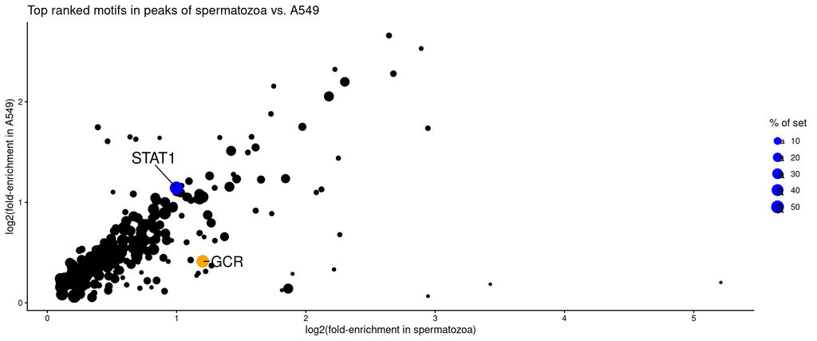

```r
ggplot(m, aes(x=log2((1+tp.sperm)/(1+fp.sperm)), y= log2((1+tp.a549)/(1+fp.a549)), size=(tp_percent.sperm))) +
  geom_point() +

  geom_point(data=gr, color="orange")+
  geom_text_repel(box.padding=0.5, min.segment.length = 0, max.overlaps = 10,  nudge_x = 0.3, direction = "x", hjust = "right", aes(label=motif_id ), data= gr)+
  geom_point(data=stat1, color="blue")+
  geom_text_repel(box.padding=0.5, min.segment.length = 0, max.overlaps = 10,  nudge_y = 0.3, direction = "y", hjust = "right", aes(label=motif_id ), data= stat1)+

  labs(color="Top enriched motifs")+
  labs(x="log2(fold-enrichment in spermatozoa)", y="log2(fold-enrichment in A549)", size="% of set") +

  theme_classic() +

  ggtitle("Top ranked motifs in peaks of spermatozoa vs. A549")
```

```r
ggsave("./sup_plots/FigS1B_motif_enrichment_sperm_vs_A549_peaks.svg")
ggsave("./sup_plots/FigS1B_motif_enrichment_sperm_vs_A549_peaks.pdf")#, width = 6, height = 4)
ggsave("./sup_plots/FigS1B_motif_enrichment_sperm_vs_A549_peaks.png")
```

# 9 Fig S1C - Sperm GRE peaks not accessible in immature germ cells across spermatogenesis

```r
tracks <- c(
  uds1="extern_data/ATACse_PRJNA399533_Thy1posSpermatogonia_GSM2751121.bw",
  uds2="extern_data/ATACse_PRJNA399533_Thy1posSpermatogonia_GSM2751122.bw",
  ds1="extern_data/ATACse_PRJNA399533_cKitposSpermatogonia_GSM2751125.bw",
  ds2="extern_data/ATACse_PRJNA399533_cKitposSpermatogonia_GSM2751126.bw",
  ps1="extern_data/ATACse_PRJNA399533_PachytenSpermatocytes_GSM2751129.bw",
  ps2="extern_data/ATACse_PRJNA399533_PachytenSpermatocytes_GSM2751130.bw",
  rs1="extern_data/ATACse_PRJNA399533_RoundSpermatides_GSM2751133.bw",
  rs2="extern_data/ATACse_PRJNA399533_RoundSpermatides_GSM2751134.bw",
  sperm1="extern_data/ATAC_PRJNA480448_Sperm_GSM3262855.bw",
  sperm2="extern_data/ATAC_PRJNA480448_Sperm_GSM3262856.bw",
  sperm3="extern_data/ATAC_PRJNA315208_Sperm_GSM2088377.bw",
  sperm4="extern_data/ATAC_PRJNA315208_Sperm_GSM2088378.bw",
  GVoocyte1="extern_data/ATAC_PRJNA480448_GVOocyte_GSM3262861.bw",
  GVoocyte2="extern_data/ATAC_PRJNA480448_GVOocyte_GSM3262862.bw",
  "MII oocyte"="extern_data/ATAC_PRJNA480448_MIIOocyte_GSM3262863.bw"
)
```

```r
peaks <- readRDS("./objects/narrow_overlaps_spermGRE_not_immatureGermCellsGRE.rds")
m <- signal2Matrix(tracks, peaks, w = 20, BPPARAM = 2)
```

```
##   |                                                                              |                                                                      |   0%  |                                                                              |=====                                                    …
```

```r
m <- epiwraps:::.ese2ml(m)

fused_uds_mat <- mergeSignalMatrices(m[1:2])
fused_ds_mat <- mergeSignalMatrices(m[3:4])
fused_ps_mat <- mergeSignalMatrices(m[5:6])
fused_rs_mat <- mergeSignalMatrices(m[7:8])
fused_sperm_mat <- mergeSignalMatrices(m[9:12])
fused_gv_mat <- mergeSignalMatrices(m[13:14])

fused_m <- c(list(fused_uds=fused_uds_mat), list(fused_ds=fused_ds_mat), list(fused_ps=fused_ps_mat), list(fused_rs=fused_rs_mat), list(fused_sperm=fused_sperm_mat), list(fused_GVoocytes=fused_gv_mat), m[15], m[-1:-15])
fused_n <- renormalizeBorders(lapply(fused_m,log1p))
```

```r
pdf("sup_plots/FigS1C_GREpeaks_from_sperm_notimmature_across_spermatogenesis.pdf", width=17.5, height=10)
h <- plotEnrichedHeatmaps(fused_m, row_title="Peaks from spermatozoa with GRE \n not accessible in immature germ cells", raster_resize_mat = FALSE, axis_name = c("-2kb","0","+2kb"), colors = rocket(2000), mean_color = "#800080")
print(h)
dev.off()
```

```r
png("sup_plots/FigS1C_GREpeaks_from_sperm_notimmature_across_spermatogenesis.png", height=768)
h <- plotEnrichedHeatmaps(fused_m, row_title="Peaks from spermatozoa with GRE", raster_resize_mat = TRUE, axis_name = c("-2kb","0","+2kb"), colors = rocket(2000), mean_color = "#800080")
print(h)
dev.off()
```

# 10 Fig S1D - Sperm GRE peaks across spermatogenesis hPTMs

Combined plot normalized

```r
tracks <- c(
  H3K4me3="extern_data//SRR5049005.bw",#sperm4
  H3K27ac="extern_data/SRR3225845.bw",#sperm1
  H3K9ac="extern_data/SRR3225847.bw" #sperm1
)

peaks <- readRDS("objects/narrow_overlaps_spermGRE_not_immatureGermCellsGRE.rds")
m <- signal2Matrix(tracks, peaks, w=20, BPPARAM = 4)
m <- epiwraps:::.ese2ml(m)


n <- renormalizeBorders(lapply(m,log1p))
```

Single panels of heatmaps

```r
# Create a list of heatmaps
for (i in 1:length(n)) {
  h <- plotEnrichedHeatmaps(n[i], raster_resize_mat = TRUE, axis_name = c("-2kb","0","+2kb"), colors = magma(2000), mean_color = "#800080",
                            heatmap_legend_param = list(legend_direction = "horizontal", legend_width = unit(0.28, "npc"), title=NULL))

  # Save each heatmap to a PDF
    pdf(paste0("sup_plots/FigS1D_GREpeaks_from_sperm_notImmature_hPTMs_normalized_", i, ".pdf"), width=2.5, height=10)
  draw(h, heatmap_legend_side="bottom", annotation_legend_side="right",  legend_grouping = "original")
  dev.off()
}
```

```r
# Create a list of heatmaps
for (i in 1:length(n)) {
  h <- plotEnrichedHeatmaps(n[i], raster_resize_mat = TRUE, axis_name = c("-2kb","0","+2kb"), colors = magma(2000), mean_color = "#800080",
                            heatmap_legend_param = list(legend_direction = "horizontal", legend_width = unit(0.4, "npc"), title=NULL))

  # Save each heatmap to a PNG
  png(paste0("sup_plots/FigS1D_GREpeaks_from_sperm_notImmature_hPTMs_normalized_", i, ".png"), width=250, height=768)
  draw(h, heatmap_legend_side="bottom", annotation_legend_side="right",  legend_grouping = "original")
  dev.off()
}
```

# 11 Fig S1E - Promoters with GRE across sperm ATAC and hPTMs

```r
tracks <- c(
  sperm1="extern_data/ATAC_PRJNA480448_Sperm_GSM3262855.bw",
  sperm2="extern_data/ATAC_PRJNA480448_Sperm_GSM3262856.bw",
  sperm3="extern_data/ATAC_PRJNA315208_Sperm_GSM2088377.bw",
  sperm4="extern_data/ATAC_PRJNA315208_Sperm_GSM2088378.bw",
  sperm1_H3K4me3="extern_data/SRR3309386.bw",
  sperm2_H3K4me3="extern_data/SRR3309387.bw",
  sperm3_H3K4me3="extern_data/SRR3703039.bw",
  sperm4_H3K4me3="extern_data/SRR5049005.bw",
  sperm5_H3K4me3="extern_data/SRR3225849.bw",
  sperm1_H3K27ac="extern_data/SRR3225845.bw",
  sperm2_H3K27ac="extern_data/SRR5049001.bw",
  sperm1_H3K9ac="extern_data/SRR3225847.bw",
  sperm2_H3K9ac="extern_data/SRR5049003.bw",
  sperm1_H3K4me1="extern_data/SRR3225848.bw",
  sperm2_H3K4me1="extern_data/SRR5049004.bw",
  sperm1_H3.3="extern_data/ChIP_PRJNA480447_Sperm_GSM3262880.bw",
  sperm2_H3.3="extern_data/ChIP_PRJNA480447_Sperm_GSM3262881.bw",
  sperm1_H2A.Z="extern_data/ChIP_PRJNA480447_Sperm_GSM3262882.bw",
  sperm2_H2A.Z="extern_data/ChIP_PRJNA480447_Sperm_GSM3262880.bw"
)



proms <- readRDS("objects/GRE_promoters_center.rds")

m <- signal2Matrix(tracks, proms, w = 20, BPPARAM = 8)
```

```
##   |                                                                              |                                                                      |   0%  |                                                                              |====                                                     …
```

```r
fused_sperm <- mergeSignalMatrices(m[,1:4])
fused_H3K4me3 <- mergeSignalMatrices(m[,5:9])
fused_H3K27ac <- mergeSignalMatrices(m[,10:11])
fused_H3K9ac <- mergeSignalMatrices(m[,12:13])
fused_H3K4me1 <- mergeSignalMatrices(m[,14:15])
fused_H3.3 <- mergeSignalMatrices(m[,16:17])
fused_H2A.Z <- mergeSignalMatrices(m[,18:19])

fused_m <- c(list(fused_sperm=fused_sperm), list(fused_H3K4me3=fused_H3K4me3), list(fused_H3K27ac=fused_H3K27ac), list(fused_H3K9ac=fused_H3K9ac), list(fused_H3K4me1=fused_H3K4me1), list(fused_H3.3=fused_H3.3), list(fused_H2A.Z=fused_H2A.Z), m[,-1:-19])
# fused_n <- renormalizeBorders(lapply(fused_m,log1p))

fused_m1 <- fused_m[1:3]
```

```r
pdf("sup_plots/FigS1E_GREpromoters.pdf", width=7, height=10)
h <- plotEnrichedHeatmaps(fused_m1, row_title="Promoter regions with GRE", raster_resize_mat = TRUE, axis_name = c("-2kb","0","+2kb"), colors = rocket(2000), mean_color = "#800080")
print(h)
dev.off()
```

```r
png("sup_plots/FigS1E_GREpromoters.png", height=768)
h <- plotEnrichedHeatmaps(fused_m1, row_title="Promoter regions with GRE", raster_resize_mat = TRUE, axis_name = c("-2kb","0","+2kb"), colors = rocket(2000), mean_color = "#800080")
print(h)
dev.off()
```

# 12 Fig S1F - Heatmap for ICR in mm10

```r
ICR <- read.csv("objects/ICR_Weber_mm10.csv",header = T)
ICR$seqnames <- ICR$X.chrom
ICR <- GRanges(ICR)

seqlevelsStyle(ICR) <- "Ensembl"

bw_mm10 <- list.files(path = "intern_data/Nanopore/",pattern = "_5mC_4reads|_5mC_(.*_noSex)",full.names = T)
names(bw_mm10) <- c("Ctrl1","Ctrl2","KO1","KO2")
```

```r
Met_bed <- sapply(names(bw_mm10),function(names){
  import.bw(bw_mm10[names])

  })
```

```r
sm <- signal2Matrix(filepaths = Met_bed,regions = ICR,w =10,type = "scaled",smooth = T,limit = c(0,100))
plotEnrichedHeatmaps(sm)
# as.data.frame(ICR)
set.seed(123)
cl <- epiwraps::clusterSignalMatrices(sm,k = 2)
cl2 <- as.character(cl)

cl2[cl2 == 1] <- ("Maternal")

cl2[cl2 == 2] <- ("Paternal")


cl2 <- as.factor(cl2)
```

```r
sm_merge_Ctrl <- mergeSignalMatrices(sm[,1:2])
```

```r
mycolors2 <- c("Maternal" = "firebrick","Paternal"= "steelblue")
p <- plotEnrichedHeatmaps(list("ICR" = sm_merge_Ctrl),row_split = cl2,scale_title = "5mC[%]",mean_color  = mycolors2, use_raster = T,heatmap_legend_param = list(legend_direction = "horizontal", legend_width = unit(0.28,"npc"), title = NULL))
```

```r
  draw(p, heatmap_legend_side="bottom", annotation_legend_side="right",  legend_grouping = "original")

  png(paste0("sup_plots/FigS1F.png"), width=250, height=500)
  draw(p, heatmap_legend_side="bottom", annotation_legend_side="right",  legend_grouping = "original")
  dev.off()
```

```r
  pdf(paste0("sup_plots/FigS1F.pdf"), width=3.5, height=7.5)
  draw(p, heatmap_legend_side="bottom", annotation_legend_side="right",  legend_grouping = "original")
  dev.off()
```

```r
  svg(paste0("sup_plots/FigS1F.svg"), width=3.5, height=7.5)
  draw(p, heatmap_legend_side="bottom", annotation_legend_side="right",  legend_grouping = "original")
  dev.off()
```

# 13 Fig S1G - Display of methlyation score distribution

```r
set.seed(1234)
Met_bed_Ctrl <- Met_bed[1:2]
df <- rbind(as.data.frame(sample(Met_bed_Ctrl$Ctrl1$score,size = 100000)),y = as.data.frame(sample(Met_bed_Ctrl$Ctrl1$score,size = 100000)))
df$score <- df$`sample(Met_bed_Ctrl$Ctrl1$score, size = 1e+05)`
df$Sample <- rep("S1",nrow(df))
df$Sample[((nrow(df)/2)+1):nrow(df)] <- "S2"
```

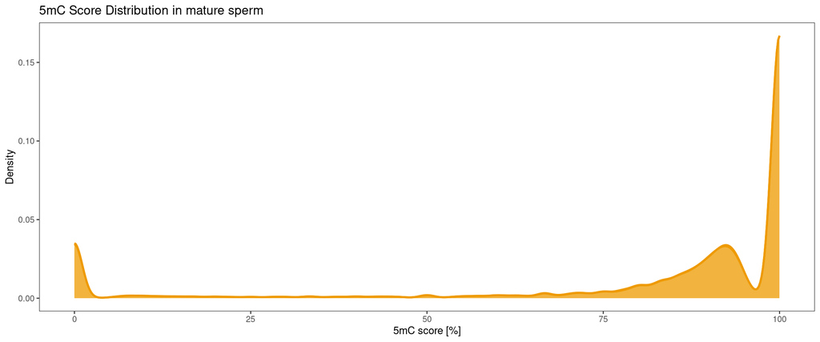

```r
ggplot(data = df,aes(x = score,group = Sample)) +

  geom_density(color = "orange2", size = 1,fill = "orange2",alpha = 0.5) +
  labs(title = "5mC Score Distribution in mature sperm", x = "5mC score [%]", y = "Density") +
  theme_bw()+theme(
    panel.grid.major = element_blank(),
    panel.grid.minor = element_blank()
  )
```

```r
ggsave("sup_plots/FigS1G_5mC_score_distribution.svg")
ggsave("sup_plots/FigS1G_5mC_score_distribution.pdf")
ggsave("sup_plots/FigS1G_5mC_score_distribution.png")
```

# 14 Fig S1H - Promoters with GRE at accesible site of ATAC H3k4me3 5mC

```r
proms <- readRDS("objects/GRE_promoters_center.rds")
```

```r
tracks <- c(
  sperm1="extern_data/ATAC_PRJNA480448_Sperm_GSM3262855.bw",
  sperm2="extern_data/ATAC_PRJNA480448_Sperm_GSM3262856.bw",
  sperm3="extern_data/ATAC_PRJNA315208_Sperm_GSM2088377.bw",
  sperm4="extern_data/ATAC_PRJNA315208_Sperm_GSM2088378.bw",
  sperm1_H3K4me3="extern_data/SRR3309386.bw",
  sperm2_H3K4me3="extern_data/SRR3309387.bw",
  sperm3_H3K4me3="extern_data/SRR3703039.bw",
  sperm4_H3K4me3="extern_data/SRR5049005.bw",
  sperm5_H3K4me3="extern_data/SRR3225849.bw",
  sperm1_H3K27ac="extern_data/SRR3225845.bw",
  sperm2_H3K27ac="extern_data/SRR5049001.bw",
  sperm1_H3K9ac="extern_data/SRR3225847.bw",
  sperm2_H3K9ac="extern_data/SRR5049003.bw",
  sperm1_H3K4me1="extern_data/SRR3225848.bw",
  sperm2_H3K4me1="extern_data/SRR5049004.bw",
  sperm1_H3.3="extern_data/ChIP_PRJNA480447_Sperm_GSM3262880.bw",
  sperm2_H3.3="extern_data/ChIP_PRJNA480447_Sperm_GSM3262881.bw",
  sperm1_H2A.Z="extern_data/ChIP_PRJNA480447_Sperm_GSM3262882.bw",
  sperm2_H2A.Z="extern_data/ChIP_PRJNA480447_Sperm_GSM3262880.bw"
)
```

```r
peaks <- readRDS("objects/narrow_peaks_with_GRE_sperm.rds")
```

```r
peaks2 <- peaks[overlapsAny(peaks,proms)]
# seqnames(peaks2)
peaks2 <- keepStandardChromosomes(peaks2,pruning.mode = "coarse")
peaks2 <- dropSeqlevels(peaks2,value = c("MT","Y","X"),pruning.mode = "coarse")
```

```r
sm_5mC <- signal2Matrix(w = 20L , smooth = T, limit = c(0,100), filepaths = methyl_bed, regions = peaks2)
```

```r
plotEnrichedHeatmaps(sm_5mC)
```

```r
sm2 <- signal2Matrix(w = 20L, filepaths = tracks[c(1:4,5:9)],regions = peaks2)
plotEnrichedHeatmaps(sm2)
```

```r
plotEnrichedHeatmaps(c(epiwraps:::.ese2ml(sm2),epiwraps:::.ese2ml(sm_5mC)),multiScale = T,show_heatmap_legend = F)
```

```r
sm_merge <- mergeSignalMatrices(epiwraps:::.ese2ml(sm2)[1:4])
sm_merge_H3K4me3 <- mergeSignalMatrices(epiwraps:::.ese2ml(sm2)[5:9])
sm_merge_5mC <- mergeSignalMatrices(epiwraps:::.ese2ml(sm_5mC)[1:2])
```

```r
p <- plotEnrichedHeatmaps(ml = list(ATAC = sm_merge,H3K4me3 = sm_merge_H3K4me3,"5mC" = sm_merge_5mC),multiScale = T,row_title = "Accessible promoters with GRE")
```

```r
# p <- plotEnrichedHeatmaps(ml = list(ATAC = sm_merge,H3K4me3 = sm_merge_H3K4me3),multiScale = T,row_title = "Accessible promoters with GRE",color = rocket(2000),scale_title = "density",axis_name = c("-2kb","TSS","+2kb"), use_raster = T,mean_scale_side = "none",  heatmap_legend_param = list(legend_direction = "horizontal", legend_width = unit(0.4,"npc"), title=NULL))+
#                        plotEnrichedHeatmaps(ml = list("5mC" = sm_merge_5mC),row_title = "Accessible promoters with GRE",use_raster =TRUE, scale_title = "5mc[%]",axis_name = c("-2kb","TSS","+2kb"),mean_scale_side = "none",  heatmap_legend_param = list(legend_direction = "horizontal", legend_width = unit(0.4,"npc"), title=NULL));p
# # p
 #draw(p, heatmap_legend_side="bottom", annotation_legend_side="right",  legend_grouping = "original")

 #draw(p, heatmap_legend_side="bottom", annotation_legend_side="right",  legend_grouping = "original")

  png(paste0("sup_plots/FigS1H.png"), width=750, height=768)
  draw(p, heatmap_legend_side="bottom", annotation_legend_side="right",  legend_grouping = "original")
  dev.off()
```

```r
  pdf(paste0("sup_plots/FigS1H.pdf"), width=7.5, height=10)
  draw(p, heatmap_legend_side="bottom", annotation_legend_side="right",  legend_grouping = "original")
  dev.off()
```

```r
  svg(paste0("sup_plots/FigS1H.svg"), width=7.5, height=10)
  draw(p, heatmap_legend_side="bottom", annotation_legend_side="right",  legend_grouping = "original")
  dev.off()
```

each heatmap on its own

```r
#ATAC
p <- plotEnrichedHeatmaps(ml = list(ATAC = sm_merge),multiScale = F,row_title = "Accessible promoters with GRE",color = rocket(2000),scale_title = "density",axis_name = c("-2kb","TSS","+2kb"), use_raster = T,  heatmap_legend_param = list(legend_direction = "horizontal", legend_width = unit(0.4,"npc"), title=NULL))
png(paste0("sup_plots/FigS1HATAC.png"), width=250, height=768)
  draw(p, heatmap_legend_side="bottom", annotation_legend_side="right",  legend_grouping = "original")
  dev.off()
```

```r
  pdf(paste0("sup_plots/FigS1HATAC.pdf"), width=2.5, height=10)
  draw(p, heatmap_legend_side="bottom", annotation_legend_side="right",  legend_grouping = "original")
  dev.off()
```

```r
  svg(paste0("sup_plots/FigS1HATAC.svg"), width=2.5, height=10)
  draw(p, heatmap_legend_side="bottom", annotation_legend_side="right",  legend_grouping = "original")
  dev.off()
```

```r
# H*K4m3
  p <- plotEnrichedHeatmaps(ml = list(H3K4me3 = sm_merge_H3K4me3),multiScale = F,row_title = "Accessible promoters with GRE",color = rocket(2000),scale_title = "density",axis_name = c("-2kb","TSS","+2kb"), use_raster = T,  heatmap_legend_param = list(legend_direction = "horizontal", legend_width = unit(0.4,"npc"), title=NULL))
png(paste0("sup_plots/FigS1HH3K4me3.png"), width=250, height=768)
  draw(p, heatmap_legend_side="bottom", annotation_legend_side="right",  legend_grouping = "original")
  dev.off()
```

```r
  pdf(paste0("sup_plots/FigS1HH3K4me3.pdf"), width=2.5, height=10)
  draw(p, heatmap_legend_side="bottom", annotation_legend_side="right",  legend_grouping = "original")
  dev.off()
```

```r
  svg(paste0("sup_plots/FigS1HH3K4me3.svg"), width=2.5, height=10)
  draw(p, heatmap_legend_side="bottom", annotation_legend_side="right",  legend_grouping = "original")
  dev.off()
```

```r
# 5mC

p <-   plotEnrichedHeatmaps(ml = list("5mC" = sm_merge_5mC),row_title = "Accessible promoters with GRE",use_raster =TRUE, scale_title = "5mc[%]",axis_name = c("-2kb","TSS","+2kb"),  heatmap_legend_param = list(legend_direction = "horizontal", legend_width = unit(0.4,"npc"), title=NULL))
png(paste0("sup_plots/FigS1H5mc.png"), width=250, height=768)
  draw(p, heatmap_legend_side="bottom", annotation_legend_side="right",  legend_grouping = "original")
  dev.off()
```

```r
  pdf(paste0("sup_plots/FigS1H5mc.pdf"), width=2.5, height=10)
  draw(p, heatmap_legend_side="bottom", annotation_legend_side="right",  legend_grouping = "original")
  dev.off()
```

```r
  svg(paste0("sup_plots/FigS1H5mc.svg"), width=2.5, height=10)
  draw(p, heatmap_legend_side="bottom", annotation_legend_side="right",  legend_grouping = "original")
  dev.off()
```

# 15 Fig S1M - GO:BP GR-ChIP

```r
library(clusterProfiler)
library(org.Mm.eg.db)
```

```r
se <- readRDS("intern_data/ChIP/GR_counts_non_resized.SE.rds")
ah <- AnnotationHub()
genome <- ah[["AH89457"]]

annGR <- transcripts(genome,
 columns = c("tx_id", "tx_biotype", "gene_id", "gene_name")
)


anno_Stress <- ChIPpeakAnno::annoPeaks(peaks = granges(se),annoData = annGR,bindingType = "fullRange",select = "bestOne")

# table(width(peaks)<=500)
```

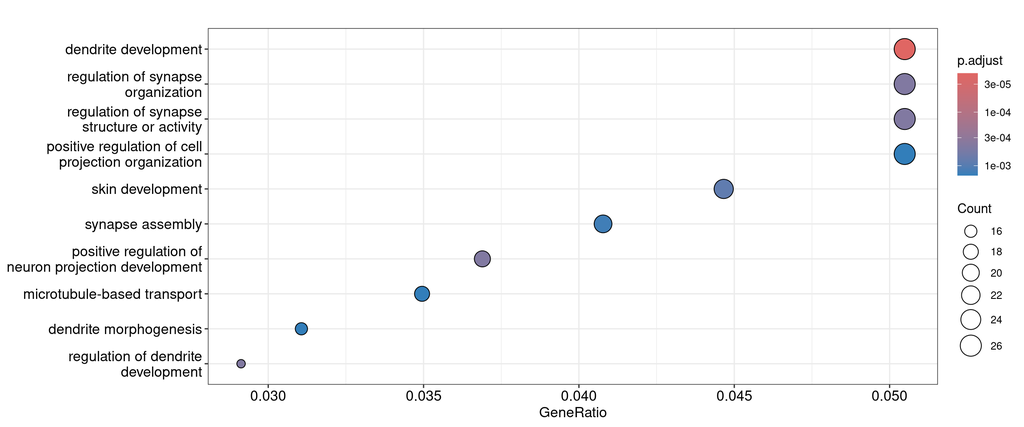

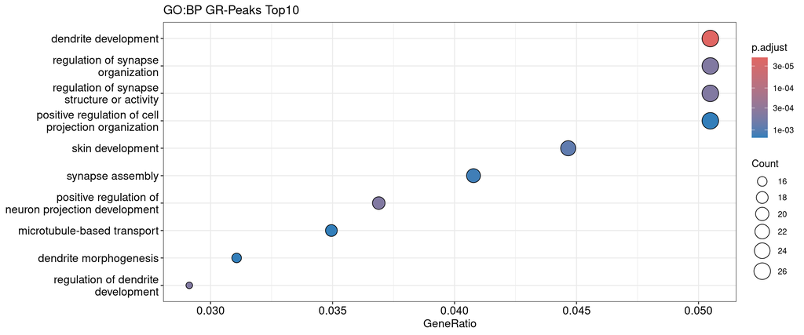

```r
set.seed(123)


  gene_list <- unlist(anno_Stress$gene_name)
  gene_list <- gene_list[!duplicated(gene_list)]

kegg <- enrichGO(gene          = gene_list,
                OrgDb         = org.Mm.eg.db,
                keyType       = "SYMBOL",
                ont           = "BP",  # BP: Biological Process, MF: Molecular Function, CC: Cellular Component
                pAdjustMethod = "BH",
                pvalueCutoff  = 1,
                qvalueCutoff  = 1

                    )





d <- dotplot(kegg, showCategory=10)
print(d)+ggtitle("GO:BP GR-Peaks Top10")
```

```r
# kegg@result
ggsave("sup_plots/FigS1M_GOBP_GRChIP.png")
ggsave("sup_plots/FigS1M_GOBP_GRChIP.pdf")
#kegg@result
```

# 16 Fig 2B - Validation of GR-KO

```r
methyl_bw2 <- list.files(path = "intern_data/Nanopore/",pattern = "_..bw$",full.names = T)
```

```r
ensdb_mm10 <- ah[["AH89211"]]
```

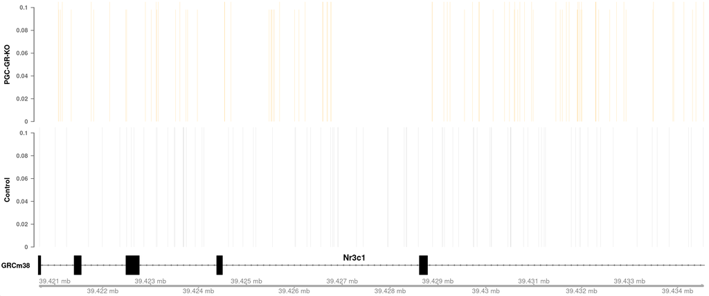

```r
plotSignalTracks(files = list( "PGC-GR-KO" = methyl_bw2[3:4], Control = methyl_bw2[1:2]),overlay.alpha = 75,region = "18:39420652-39434571",aggregation = "overlay",colors = c("orange","darkgrey"),genomeAxis = T,ensdb = ensdb_mm10,extend = c(0,0), fontface.main = 1,cex.main = 1,cex.id=0.9,cex.title = 0.7, ylim = c(0,0.1),) # , rotation.title = 0
grid.text(paste0("Nr3c1"), x = 0.5, y = 0.13, gp = gpar(fontsize = 10, fontface = "bold"))
```

```r
png(paste0("plots/Fig2B.png"), width=750, height=512)
plotSignalTracks(files = list( "PGC-GR-KO" = methyl_bw2[3:4], Control = methyl_bw2[1:2]),overlay.alpha = 75,region = "18:39420652-39434571",aggregation = "overlay",colors = c("orange","darkgrey"),genomeAxis = T,ensdb = ensdb_mm10,extend = c(0,0), fontface.main = 1.4,cex.main = 1,cex.id=0.9,cex.title = 0.9, ylim = c(0,0.1),) # , rotation.title = 0
grid.text(paste0("Nr3c1"), x = 0.5, y = 0.15, gp = gpar(fontsize = 15, fontface = "bold"))
dev.off()
```

```r
pdf(paste0("plots/Fig2B.pdf"), width=8, height=7,colormodel = "cymk")
plotSignalTracks(files = list( "PGC-GR-KO" = methyl_bw2[3:4], Control = methyl_bw2[1:2]),overlay.alpha = 75,region = "18:39420652-39434571",aggregation = "overlay",colors = c("orange","darkgrey"),genomeAxis = T,ensdb = ensdb_mm10,extend = c(0,0), fontface.main = 1.4,cex.main = 1,cex.id=0.9,cex.title = 0.9, ylim = c(0,0.1),) # , rotation.title = 0
grid.text(paste0("Nr3c1"), x = 0.5, y = 0.15, gp = gpar(fontsize = 15, fontface = "bold"))
dev.off()
```

```r
svg(paste0("plots/Fig2B.svg"), width=8, height=7)
plotSignalTracks(files = list( "PGC-GR-KO" = methyl_bw2[3:4], Control = methyl_bw2[1:2]),overlay.alpha = 75,region = "18:39420652-39434571",aggregation = "overlay",colors = c("orange","darkgrey"),genomeAxis = T,ensdb = ensdb_mm10,extend = c(0,0), fontface.main = 1.4,cex.main = 1,cex.id=0.9,cex.title = 0.9, ylim = c(0,0.1),) # , rotation.title = 0
grid.text(paste0("Nr3c1"), x = 0.5, y = 0.15, gp = gpar(fontsize = 15, fontface = "bold"))
dev.off()
```

# 17 Fig 2C DMRs PGC-GR-KO sperm heatmap

regions of interest

```r
HyperDMR <- readRDS("objects/hyper_mm39.rds")
HypoDMR <- readRDS("objects/hypo_mm39.rds")

DMR <- unlist(GRangesList(HyperDMR,HypoDMR))
```

```r
i <- integer(length(DMR))
i[1:(length(HyperDMR))] <- "HyperDMR"
i[((length(HyperDMR))+1):length(DMR)] <- "HypoDMR"
```

tracks

```r
#NanoporeTracks
methyl_bw <- list.files(path = "intern_data/Nanopore/",pattern = "39.bw",full.names = T)
names(methyl_bw) <- c("Control 1","Control 2","PGC-GR-KO 1","PGC-GR-KO 2")
```

```r
methyl_bed <- sapply(names(methyl_bw),function(names){
  import.bw(methyl_bw[names])

  })
```

initial heatmap of DMRs smooth

```r
sm1 <- signal2Matrix(filepaths = methyl_bed,w = 20,regions = DMR,smooth = T,limit = c(0,100))
```

```r
mycolors <- c("HyperDMR"="#ffa500ff", "HypoDMR"= "#c0c0ffff")
p <- plotEnrichedHeatmaps((sm1),row_split = i,scale_rows = F,mean_color = mycolors,mean_scale_side = "left", top_annotation = TRUE,scale_title = "5mC [%]",axis_name = c("-2kb","0","+2kb"),row_title = "DMRs")

p
```

```r
mycolors <- c("HyperDMR"="#ffa500ff", "HypoDMR"= "#c0c0ffff")
p <- plotEnrichedHeatmaps((sm1),row_split = i,scale_rows = F,mean_color = mycolors,mean_scale_side = "left", top_annotation = TRUE,scale_title = "5mC [%]",axis_name = c("-2kb","0","+2kb"),row_title = "DMRs", heatmap_legend_param = list(legend_direction = "horizontal", legend_width = unit(0.28, "npc"), title=NULL))

p
```

```r
  png(paste0("plots/Fig2C.png"), width=1000, height=768)
  draw(p, heatmap_legend_side="bottom", annotation_legend_side="right",  legend_grouping = "original")
  dev.off()
```

```r
  pdf(paste0("plots/Fig2C.pdf"), width=10, height=10)
  draw(p, heatmap_legend_side="bottom", annotation_legend_side="right",  legend_grouping = "original")
  dev.off()
```

```r
  svg(paste0("plots/Fig2C.svg"), width=10, height=10)
  draw(p, heatmap_legend_side="bottom", annotation_legend_side="right",  legend_grouping = "original")
  dev.off()
```

# 18 Fig 2D DMRs overlapping with GRE in promoter heatmap

```r
ensdb <- ah[["AH89457"]] # GRCm39

promoters <- promoters(ensdb)
```

we use fimo to get GRE in all promoters

```r
genome <- Rsamtools::FaFile("objects/Mus_musculus.GRCm39.dna_sm.primary_assembly.fa")

GRE_promoters <- readRDS("objects/reduced_GRE_promoters_mm39.rds")
```

```r
DMR_GRE_prom <- DMR[overlapsAny(DMR,GRE_promoters)]

DMR_GRE_up <- HyperDMR[overlapsAny(HyperDMR,GRE_promoters)]

DMR_GRE_down <- HypoDMR[overlapsAny(HypoDMR,GRE_promoters)]


DMR_GRE_both <- unlist(GRangesList(DMR_GRE_up,DMR_GRE_down))
```

initial heatmap of DMRs smooth

```r
sm1 <- signal2Matrix(filepaths = methyl_bed,w = 20,regions = DMR_GRE_both,smooth = T,limit = c(0,100))
```

```r
i <- integer(length(DMR_GRE_both))
i[1:(length(DMR_GRE_up))] <- "HyperDMR"
i[((length(DMR_GRE_up))+1):length(DMR_GRE_both)] <- "HypoDMR"
```

```r
mycolors <- c("HyperDMR"="#ffa500ff", "HypoDMR"= "#c0c0ffff")
p <- plotEnrichedHeatmaps((sm1),row_split = i,mean_color = mycolors,scale_rows = F, mean_scale_side = "left", top_annotation = TRUE,scale_title = "5mC [%]",row_title = "DMRs overlapping GRE-sites in Promoters",axis_name = c("-2kb","GRE","+2kb"))

p
```

```r
mycolors <- c("HyperDMR"="#ffa500ff", "HypoDMR"= "#c0c0ffff")
p <- plotEnrichedHeatmaps((sm1),row_split = i,mean_color = mycolors,scale_rows = F, mean_scale_side = "left", top_annotation = TRUE,scale_title = "5mC [%]",row_title = "DMRs overlapping GRE-sites in Promoters", axis_name = c("-2kb","GRE","+2kb") ,heatmap_legend_param = list(legend_direction = "horizontal", legend_width = unit(0.28, "npc"), title=NULL),use_raster = T,trim = c(0.0001,0.9999))

p
```

```r
  png(paste0("plots/Fig2D.png"), width=1000, height=768)
  draw(p, heatmap_legend_side="bottom", annotation_legend_side="right",  legend_grouping = "original")
  dev.off()
```

```r
  pdf(paste0("plots/Fig2D.pdf"), width=10, height=10)
  draw(p, heatmap_legend_side="bottom", annotation_legend_side="right",  legend_grouping = "original")
  dev.off()
```

```r
  svg(paste0("plots/Fig2D.svg"), width=10, height=10)
  draw(p, heatmap_legend_side="bottom", annotation_legend_side="right",  legend_grouping = "original")
  dev.off()
```